# DSPM - Assignment 5

Submitted by Lukas Günner (Student-ID: 5393972)

02/10/2021

I worked together with Max Haberl (Student ID: 5407084). I hereby assure that my submission is in line with the *Code of Conduct* outlined on the lecture slides.

The working history for this assignment can be accessed via this link:

https://github.com/LukasGuenner/Assignment_5_Guenner.git

## Preparation

Before starting this assignment, I am clearing my workspace and console and then loading the packages, necessary to complete this assignment.

```r
rm(list = ls()); cat("\014")
```

```r
library(tidyverse)
library(naniar)
library(dplyr)
```

## Getting to know the API

I am sourcing my API key from a separate script not included in the GitHub repository.

```r
# loading API key from separate file
source("ticketmasterKey.R")
```

Information on the API:

After familiarizing with the API functionality and documentation, the following information is relevant for my application. The rate limits are 5000 API calls per day and there is a rate limitation of 5 requests per second! Further there is another limitation for Deep Paging: we only support retrieving the 1000th item. i.e. ( size * page < 1000). This however is not relevant for me as the venues for Germany and France do not exceed 1000 pages.

```r
# information from the API documentation
root <- "https://app.ticketmaster.com/discovery/v2/"
```

## Interaction with the API - the basics

```r
# loading required packages
if (!require("jsonlite")) install.packages("jsonlite")
if (!require("httr")) install.packages("httr")
if (!require("rlist")) install.packages("rlist")

library(jsonlite)
library(httr)
library(rlist)
```

```r
# Making the first API call to obtain venues in Germany

country <- "DE"  # define country
countryLong <- "Germany"

# perform GET request
venuesResp <- GET(paste0(root, "venues?apikey=", mykey,
                     "&locale=*&countryCode=", country)) %>%
  content()

# subset list to venue data
subset <- venuesResp[["_embedded"]][["venues"]]

# initialize data frame to store information
venues <- data.frame(name = character(),
                     city = character(),
                     adress = character(),
                     postalCode = integer(),
                     countryCode = character(),
                     url = character(),
                     longitude = numeric(),
                     latitude = numeric(),
                     stringsAsFactors=FALSE)

# extract data from list
for (i in 1:20){
  name <- subset[[i]]$name
  city <- subset[[i]]$city$name
  address <- subset[[i]]$address$line1
  postalCode <- subset[[i]]$postalCode
  countryCode <- subset[[i]]$country$countryCode
  url <- subset[[i]]$url
  longitude <- subset[[i]]$location$longitude
  latitude <- subset[[i]]$location$latitude

  venues[i, ] <- c(name, city, address, postalCode, countryCode, url,
                   longitude, latitude)
}

glimpse(venues)
```

```
## Rows: 20
## Columns: 8
## $ name        <chr> "Gruenspan", "Philharmonie (Großer Saal)", "Beatpol", "MH…
## $ city        <chr> "Hamburg", "Berlin", "Dresden", "Ludwigsburg", "Berlin", …
## $ adress      <chr> "Grosse Freiheit 58", "Herbert-von-Karajan-Straße 1", "Al…
## $ postalCode  <chr> "22767", "10785", "01157", "71638", "12435", "79108", "70…
## $ countryCode <chr> "DE", "DE", "DE", "DE", "DE", "DE", "DE", "DE", "DE", "DE…
## $ url         <chr> "http://www.ticketmaster.de/venue/287155", "https://www.t…
## $ longitude   <chr> "9.958075", "13.36896", "13.67471", "9.1824", "13.42054",…
## $ latitude    <chr> "53.551885", "52.51007", "51.06498", "48.89121", "52.4994…
```

After performing the GET request, I obtain a list consisting of three lists itself. One containing the venue information, one with links that specify the directory paths to access different pages and current information and one list informing about the number of pages, elements and total information available. The lists contain nested lists themselves. Simply applying *list.stack()* to the venues list is thus not possible. Using the list structure, each information peace to be extracted is therefore addressed individually and aggregated via a loop. This enables me to collect the data in a data frame as displayed here.

## Interacting with the API - advanced

I am now extending data extraction by extracting all possible venue locations in Germany from all available pages. For this I am using a loop to loop through all the pages with a nested loop to loop through each list, as done above. To access individual pages I simply have to add the *&page=x* parameter to the url. The response object I then obtain are the same ones as above, which enables me to employ the same method for extracting the data.

```r
# get number of pages
pages <- venuesResp[["page"]][["totalPages"]]

# number of elements to check after the loop
elements <- venuesResp[["page"]][["totalElements"]]

for (j in 1:pages){
  venuesResp2 <- GET(paste0(root, "venues?apikey=", mykey,
                     "&locale=*&page=", j, "&countryCode=", country)) %>%
    content()

  # subset list to venue data
  subset <- venuesResp2[["_embedded"]][["venues"]]

  # number of venues on page
  size <- length(venuesResp2[["_embedded"]][["venues"]])

  venues2 <- data.frame(name = character(size),
                     city = character(size),
                     adress = character(size),
                     postalCode = integer(size),
                     countryCode = character(size),
                     url = character(size),
                     longitude = numeric(size),
                     latitude = numeric(size),
                     stringsAsFactors=FALSE)

  for (i in 1:size){
  name <- ifelse(is.null(subset[[i]]$name), NA, subset[[i]]$name)
  city <- ifelse(is.null(subset[[i]]$city$name), NA, subset[[i]]$city$name)
  address <- ifelse(is.null(subset[[i]]$address$line1), NA, subset[[i]]$address$line1)
  postalCode <- ifelse(is.null(subset[[i]]$postalCode), NA, subset[[i]]$postalCode)
  countryCode <- ifelse(is.null(subset[[i]]$country$countryCode), NA,
                        subset[[i]]$country$countryCode)
  url <- ifelse(is.null(subset[[i]]$url), NA, subset[[i]]$url)
  longitude <- ifelse(is.null(subset[[i]]$location$longitude), NA,
                      subset[[i]]$location$longitude)
  latitude <- ifelse(is.null(subset[[i]]$location$latitude), NA,
                     subset[[i]]$location$latitude)

  venues2[i , ] <- c(name, city, address, postalCode, countryCode, url,
                   longitude, latitude)
  }
  venues <- rbind(venues, venues2)
}
```

The following map displays all German event venues scattered across Germany.

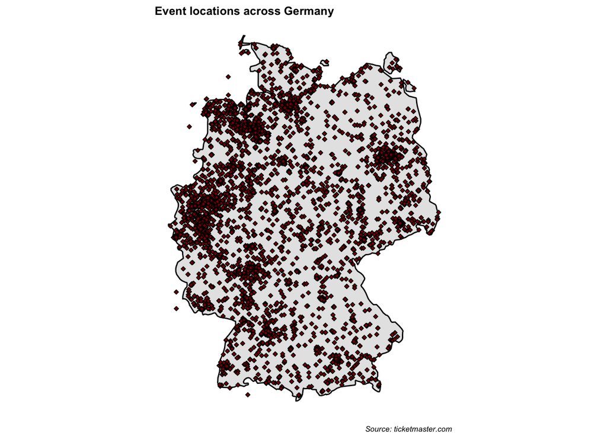

```r
library(ggplot2)

# change format for filtering
venues$longitude <- as.numeric(venues$longitude)
venues$latitude <- as.numeric(venues$latitude)

# only select the ones in the coordinate range
venuesDE <- filter(venues, longitude > 5.866944 & longitude < 15.043611 &
                     latitude > 47.271679 & latitude < 55.0846)

# using the code given in task
mapDE <- ggplot() + geom_polygon(
  aes(x = long, y = lat, group = group), data = map_data("world", region = countryLong),
  fill = "grey90",color = "black") +
  theme_void() + coord_quickmap() +
  geom_point(data = venuesDE, aes(x = longitude, y = latitude), size = 1,
        shape = 23, fill = "darkred") +
  labs(title = paste0("Event locations across ", countryLong),
       caption = "Source: ticketmaster.com") +
  theme(title = element_text(size=8, face='bold'),
        plot.caption = element_text(face = "italic"))
mapDE
```

## Event locations in another country

The analysis done above is now repeated for another European country. I selected France as my choice. Repeating the analysis is rather easy, as all I had to change in the code was the country defined as a variable in the beginning and the coordinate ranges for the venues included in the map. I then copied the code from above, adjusted the variables and ran the analysis for France providing me with the map seen below. One could make the repetition process more efficient by specifying the analysis above as a function with input arguments country and coordinate ranges, so that one would only have to call the function again for considering a different country.

```
## Rows: 20
## Columns: 8
## $ name        <chr> "Stade Pierre-Mauroy", "Le Trabendo", "Stade Chaban-Delma…
## $ city        <chr> "Villeneuve-d'Ascq", "Paris", "Bordeaux", "Paris", "Madel…
## $ adress      <chr> "261 Boulevard de Tournai", "Parc de la Villette, 211 Ave…
## $ postalCode  <chr> "59650", "75019", "33000", "75012", "62170", "06500", "75…
## $ countryCode <chr> "FR", "FR", "FR", "FR", "FR", "FR", "FR", "FR", "FR", "FR…
## $ url         <chr> "https://www.ticketmaster.be/venue/stade-pierre-mauroy-vi…
## $ longitude   <chr> "3.1305", "2.39026", NA, "2.378568", "1.75239", "7.527968…
## $ latitude    <chr> "50.61191", "48.8938489", NA, "48.838721", "50.470086", "…
```

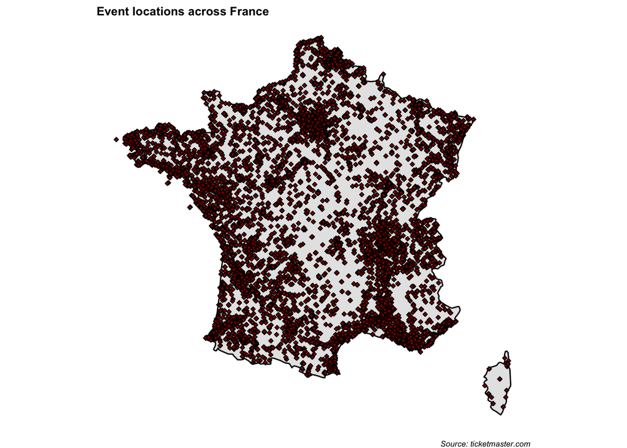

This concludes the assignment. All programming steps and implementations can be followed on GitHub via the repository link given above.